# 3d_diag_demo

## New 3D diagnostics in ORB5

*T Hayward-Schneider*, *March 2019*

#### input variables

```
nfreq_3d                       <-- how often the diagnostic should run
nsel_3d_diag = real / rhs_f    <-- which 3D diagnostic should run (real = old, rhs_f = new)
```

```
potsp:
```

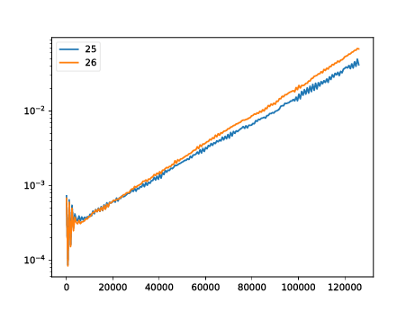

```python
from IPython.display import Image
fig = Image(filename=('fft_modes_n_at_peaks.png'))
print('potsp:')
fig
```

```
potsc:
```

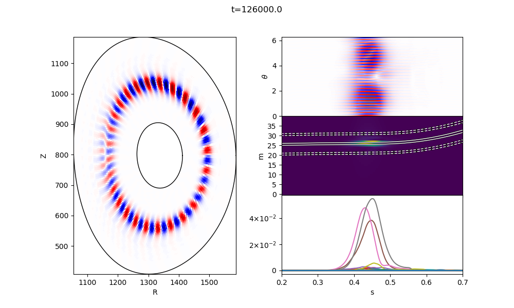

```python
fig = Image(filename=('phi_quad_plots_at_t126000.0.png'))
print('potsc:')
fig
```

```
potsp:
```

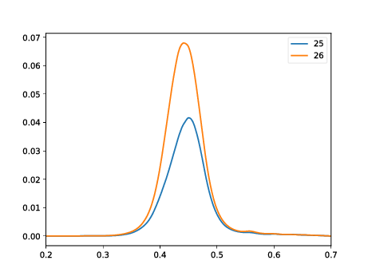

```python
#! convert fft_modes_n_at_t126000.0.pdf fft_modes_n_at_t126000.0.png
fig = Image(filename=('fft_modes_n_at_t126000.0.png'))
print('potsp:')
fig
```

```python
import h5py
import numpy as np
import orb5_utils
import orb5_3d_utils
import matplotlib.pyplot as plt
%matplotlib inline
#%matplotlib notebook
```

```python
from ipywidgets import interact, interactive, fixed, interact_manual
import ipywidgets as widgets
```

```python
import plot_sig_noise
```

```python
orbp = orb5_3d_utils.orb5_3d_data()
orbp.load_hdf5()
orbp.load_phi3d()
orbp.load_nmodes()
```

```python
print(orbp.n_mode_numbers)
print(orbp.n_mode_numbers_nft)
```

```
[25, 26]
[25, 26]
```

```python
n_ffts = orbp.n_fft()
```

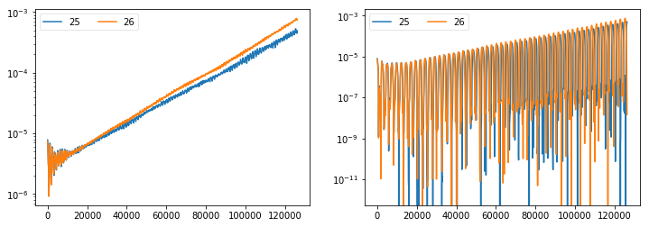

```python
fig, (ax1,ax2) = plt.subplots(1,2, figsize=(12,4))
for intor, ntor in enumerate(orbp.n_mode_numbers):
    if ntor not in orbp.n_mode_numbers_nft:
        continue
    ax1.plot(orbp.p3t[:], np.max( np.abs(n_ffts[:,intor,:]), axis=1), label=ntor)
    ax2.plot(orbp.p3t[:], np.max(np.real(n_ffts[:,intor,:]), axis=1), label=ntor)
#    ax3.plot(orbp.p3t[:], np.max(np.imag(n_ffts[:,intor,:]), axis=1), label=ntor)
for axi in [ax1,ax2]:
    axi.set_yscale('log')
    axi.legend(framealpha=0.5, fancybox=True, loc='best', ncol=2)
```

```python
orbp.set_radial_offsets()
orbp.radial_offsets
orbp.load_serial()
```

```python
sub_kwargs={"figsize":(8,8)}
```

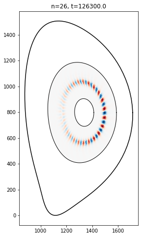

```python
nrange=(min(orbp.n_mode_numbers), max(orbp.n_mode_numbers), orbp.nft)
itrange=widgets.IntSlider(min=0, max=orbp.p3t.shape[0]-1, value=orbp.p3t.shape[0]-1)
#@interact_manual(ntor=nrange,itime=itrange,savefig=False, outline_eq=False, all_modes=False)
def plot_pscs_t_on_fly(ntor=None, itime=None, savefig=None, outline_eq=False, all_modes=False):
    if ntor not in orbp.n_mode_numbers_nft:
        return
    fig, ax = plt.subplots(**sub_kwargs)
    if all_modes:
        ntitle="all"
        nlist = orbp.n_mode_numbers_nft
    else:
        ntitle=str(ntor)
        nlist = [ntor]
    psc_arr = np.real(orbp.create_potsc(itime, nchi=None, nlist=nlist))
    _ = orbp.plot_psc(psc_arr, fig=fig, ax=ax, aspect=1, cmap='RdBu_r', sym_clim=True, outline=True, outline_eq=outline_eq)
#    ntitle = str(ntor) if ntor != -1 else "all"
    ax.set_title('n={}, t={}'.format(ntitle, orbp.p3t[itime]))
    if savefig:
        fig_filename='psc_n{}_at_t{}.png'.format(ntitle, orbp.p3t[itime])
        fig.savefig(fig_filename)
        print("fig saved to {}".format(fig_filename))
    return fig, ax
fig, ax = plot_pscs_t_on_fly(ntor=26, itime=-1, outline_eq=True)
```

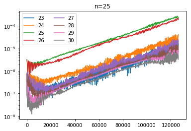

```python
mlist=None
mlsb=2
musb=5
nrange=(min(orbp.n_mode_numbers),max(orbp.n_mode_numbers),orbp.nft)
#@interact(ntor=nrange,savefig=False, save_all=False)
def pfn_obj(ntor=None, savefig=None, save_all=False):
    if save_all:
        for ntor in orbp.n_mode_numbers_nft:
            mlist = [ntor+i for i in np.arange(-mlsb,+musb+1)]
            fig, ax = orbp.plot_fft_modes_at_peaks(ntor=ntor, savefig=True, mlist=mlist)
    else:
        mlist = [ntor+i for i in np.arange(-mlsb,+musb+1)]
        fig, ax = orbp.plot_fft_modes_at_peaks(ntor=ntor, savefig=savefig, mlist=mlist)
    return fig, ax
fig, ax = pfn_obj(ntor=25)
```

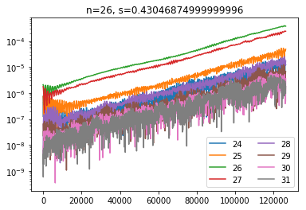

```python
"""
Caveat w.r.t. radial coordinate
"""
mlist=None
nrange=(min(orbp.n_mode_numbers),max(orbp.n_mode_numbers),orbp.nft)
sfmin=orbp.orb5s.h5['/parameters/fields/sfmin'][0]
sfmax=orbp.orb5s.h5['/parameters/fields/sfmax'][0]
sfrange=widgets.FloatSlider(min=sfmin,max=sfmax,step=0.01,value=0.5)
#@interact(ntor=nrange, spos=sfrange, savefig=False, save_all=False)
def pfns_obj(ntor=None, savefig=None, spos=None, save_all=False):
    if save_all:
        for ntor in orbp.n_mode_numbers_nft:
            mlist = [ntor+i for i in np.arange(-mlsb,+musb+1)]
            fig, ax = orbp.plot_fft_modes_at_spos(ntor=ntor, spos=spos, savefig=True, mlist=mlist)
    else:
        mlist = [ntor+i for i in np.arange(-mlsb,+musb+1)]
        fig, ax = orbp.plot_fft_modes_at_spos(ntor=ntor, spos=spos, savefig=savefig, mlist=mlist)
    return fig, ax
fig, ax = pfns_obj(ntor=26, spos=0.43)
```

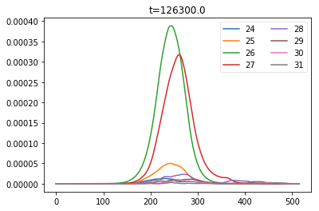

```python
def plot_m_of_n_at_t(ntor=None, imode=None, itime=None, time=1E6, savefig=False, full_range=True):
    fig, ax = plt.subplots()
    if itime is None:
        itime = np.argmin(np.abs(orbp.p3t[:] - time))
    if imode is None:
        imode, = np.arange(len(orbp.n_mode_numbers))[np.array(orbp.n_mode_numbers)==ntor]
    if full_range:
        mmin = orbp.mharms[imode].min()
        mmax = orbp.mharms[imode].max()
    else:
        mmin = ntor - mlsb
        mmax = ntor + musb
    for iharm, mharm in enumerate(np.arange(mmin, mmax+1)):
        harm = np.sum(orbp.p3dz[itime,imode]*(orbp.mharms[imode]==mharm), axis=1)
        ax.plot(np.abs(harm), label=mharm)
    ax.legend(loc='best', framealpha=0.5, ncol=2)
    ax.set_title("t={}".format(orbp.p3t[itime]))
    if savefig:
        fig.savefig('mharms_in{}_it{}.pdf'.format(imode, itime))

nrange=(min(orbp.n_mode_numbers),max(orbp.n_mode_numbers),orbp.nft)
itrange=widgets.IntSlider(min=0, max=orbp.p3t.shape[0]-1, value=orbp.p3t.shape[0]-1, continuous_update=False)
#@interact(ntor=nrange, itime=itrange, savefig=False, full_range=False)
def plot_m_of_n_at_t_jup(ntor=None, itime=None, savefig=False, full_range=False):
    return plot_m_of_n_at_t(ntor=ntor, itime=itime, savefig=savefig, full_range=full_range)

plot_m_of_n_at_t(ntor=26, itime=-1, full_range=False)
```

```python
nrange=(min(orbp.n_mode_numbers),max(orbp.n_mode_numbers),orbp.nft)
mrange=widgets.IntSlider(min=0,max=100,value=25)
@interact_manual(mharm=mrange, ntor=nrange, imode=fixed(None))
def m_s_of_t(mharm=-1, imode=None, ntor=None):
    if imode is None:
        imode, = np.arange(len(orbp.n_mode_numbers))[np.array(orbp.n_mode_numbers)==ntor]
    mamp = np.zeros((orbp.p3t.shape[0], orbp.ns_), dtype=np.complex64)
    tmp = orbp.mharms[imode]
    if mharm > tmp.min() and mharm < tmp.max():
        for itime, time in enumerate(orbp.p3t[:]):
            mamp[itime,:] = np.sum(orbp.p3dz[itime,imode]*(tmp==mharm), axis=1)
    st_grid = np.meshgrid(np.arange(orbp.ns_), orbp.p3t[:])
    im = plt.pcolormesh(st_grid[0], st_grid[1], np.real(mamp), cmap='RdBu_r')
    im.set_clim(np.array([-1,1])*np.max(np.abs(im.get_clim())))
```

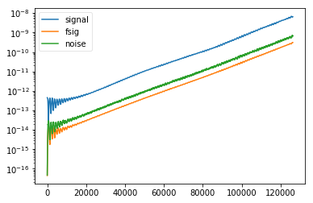

```python
fig, ax = plot_sig_noise.plot_sig_noise()
```

```python
orb = orb5_utils.orb5_data()
orb.load_hdf5()
orb.load_phi(phi_2d_type='potsp')
p2pt = orb.phi_2d['time']
@interact(itime=widgets.IntSlider(min=0, max=len(p2pt[:])-1, values=len(p2pt[:]-1), continuous_update=False))
def plot_n_of_s_at_t(itime=-1):
    fig, ax = orb.plot_fft_modes_at_t(itime, ifreqlist=orbp.n_mode_numbers_nft)
    ax.set_title("t={}".format(p2pt[itime]));
```

```python
print('Miscellaneous extra')
```

```
Miscellaneous extra
```

```python
fp = h5py.File('orb5_res_parallel.h5', 'r')
```

```python
p3 = fp['/data/var3d/generic/pot3d/']
```

```python
p3d = p3['data']
p3t = p3['time']
p3m = p3['mmin']
```

```python
# p3dz = (p3d['real'] + 1j*p3d['imaginary'])
p3dz = p3d
```

```python
#orb = orb5_utils.orb5_data()
#orb.load_hdf5()
orb = orbp.orb5s
```

```python
p2c = orb.h5['/data/var2d/generic/potsc']
p2cd = p2c['data']
p2ct = p2c['time']
p2cr = p2c['rsc']
p2cz = p2c['zsc']
p2cs = p2c['coord1']
p2cc = p2c['coord2']
```

```python
p2p = orb.h5['/data/var2d/generic/potsp']
p2pd = p2p['data']
p2pt = p2p['time']
p2ps = p2p['coord1']
p2pp = p2p['coord2']
```

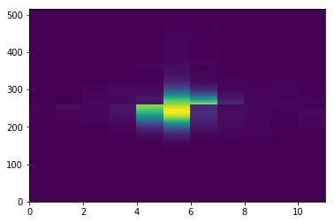

```python
plt.pcolormesh(np.abs(p3dz[-1,-1,:,:]))
```

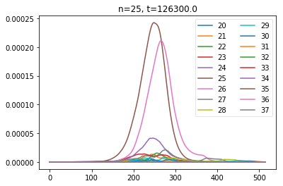

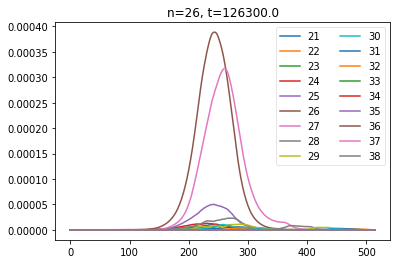

```python
full_range = True
savefig = False
#a = np.meshgrid(np.arange(p3d.shape[3]), np.arange(p3d.shape[2]))
#b = a[0]
for imode in range(p3m.shape[0]):
    if orbp.n_mode_numbers[imode] not in orbp.n_mode_numbers_nft:
        continue
    ntor = orbp.n_mode_numbers[imode]
    fig, ax = plt.subplots()
    itime = -1
    time = p3t[itime]
    #tmp = np.abs(np.array([p3m[imode]]).transpose() + b)
    tmp = orbp.mharms[imode]
    if full_range:
        mmin = tmp.min()
        mmax = tmp.max()
    else:
        mmin = 5
        mmax = 12
    for iharm, mharm in enumerate(np.arange(mmin, mmax+1)):
        harm = np.sum(p3dz[itime,imode]*(tmp==mharm), axis=1)
        ax.plot(np.abs(harm), label=mharm)
    ax.set_title("n={}, t={}".format(ntor, time))
    #ax.plot(np.sum(np.abs(p3dz[itime,imode])/2, axis=1), 'k:', label="env.")
    ax.legend(loc='best', framealpha=0.5, ncol=2)
    if savefig:
        fig.savefig('diag_3drhsf_in{}_it{}.pdf'.format(imode, itime))
```

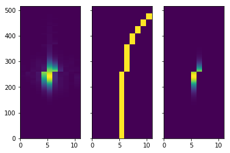

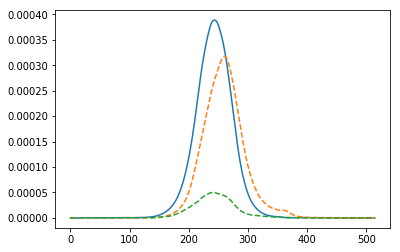

```python
mharm = 26
imode = -1
tmp = orbp.mharms[imode]
fig, axarr = plt.subplots(1,3, sharey=True)
fig2, ax = plt.subplots()
axarr[0].pcolormesh(np.abs(p3dz[-1,imode]))
axarr[1].pcolormesh((tmp == mharm))
axarr[2].pcolormesh(np.abs(p3dz[-1,imode]) * (tmp==mharm))
ax.plot(np.sum(np.abs(p3dz[-1,imode]) * (tmp==mharm), axis=1), linestyle='-')
ax.plot(np.sum(np.abs(p3dz[-1,imode]) * (tmp==mharm+1), axis=1), linestyle='--')
ax.plot(np.sum(np.abs(p3dz[-1,imode]) * (tmp==mharm+-1), axis=1), linestyle='--')
#fig.tight_layout()
#fig.savefig('m{}_summary.pdf'.format(mharm))
```

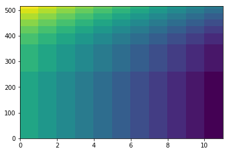

```python
plt.pcolormesh(tmp)
```

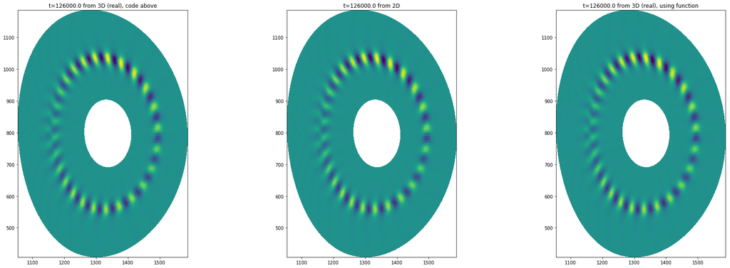

```python
time = 1.E6
itime_2d = np.argmin(np.abs(p2ct[:] - time))
time_2d = p2ct[itime_2d]
itime_3d = np.argmin(np.abs(p3t[:] - time_2d))

ns = p3dz.shape[2]-2
nchi = p2cc.shape[0]-1

sgrid = p2cs
chigrid = 2*np.pi*(np.arange(nchi+1) / nchi)
potsc_c = np.zeros((nchi+1, ns), dtype=np.complex64)
for imode, ntor in enumerate(orbp.n_mode_numbers):
    if ntor not in orbp.n_mode_numbers_nft:
        continue

    for ispos in range(ns):
        for im in np.arange(p3dz.shape[3]):
#            mharm = tmp[ispos, im]
            mharm = orbp.mharms[imode][ispos,im]
            potsc_c[:,ispos] = potsc_c[:,ispos] + (p3dz[itime_3d, imode, ispos, im] * np.exp(1j * mharm * chigrid))

fig, axarr = plt.subplots(1,3, figsize=(30,10))
axarr[0].pcolormesh(p2cr, p2cz, np.real(potsc_c))
axarr[0].set_aspect(1)
axarr[0].set_title("t={} from 3D (real), code above".format(p3t[itime_3d]));

axarr[1].pcolormesh(p2cr, p2cz, p2cd[itime_2d])
axarr[1].set_aspect('equal')
axarr[1].set_title("t={} from 2D".format(p2ct[itime_2d]));

#axarr[2].pcolormesh(p2cr, p2cz, np.imag(potsc_c))
#axarr[2].set_aspect(1)
#axarr[2].set_title("t={} from 3D (imag)".format(p3t[itime_3d]));


psc = np.real(orbp.create_potsc(itime_3d))
axarr[2].pcolormesh(p2cr, p2cz, psc)
axarr[2].set_aspect(1)
axarr[2].set_title("t={} from 3D (real), using function".format(p3t[itime_3d]));
```

```
126000.0 126000.0
```

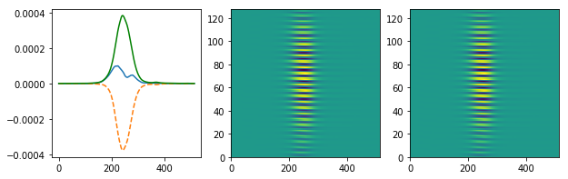

```python
time = 1.e6
itime_2d = np.argmin(np.abs(p2ct[:] - time))
time_2d = p2ct[itime_2d]
itime_3d = np.argmin(np.abs(p3t[:] - time_2d))
time_3d = p3t[itime_3d]
print(time_2d, time_3d)
itime = itime_3d
chi_ref = 0.0
ichi = np.argmin(np.abs(p2cc[:] - chi_ref))

fig, axarr = plt.subplots(1,3, figsize=(10,3))

axarr[0].plot(np.real(potsc_c[ichi,:]))
axarr[0].plot(np.imag(potsc_c[ichi,:]), '--')
axarr[0].plot(np.abs( potsc_c[ichi,:]), 'g-')

ns = p3dz.shape[2]-2
nphi = p2pp.shape[0]


if chi_ref == 0.0:
    potsc_c_slice = np.sum(p3dz[itime,:,:-2,:], axis=2)
else:
    potsc_c_slice = potsc_c[ichi,:-2]

sgrid = p2cs
phigrid = 2*np.pi*(np.arange(nphi) / nphi)
potsp = np.zeros((nphi, ns), dtype=np.complex64)
for imode, ntor in enumerate(orbp.n_mode_numbers):
    if ntor not in orbp.n_mode_numbers_nft:
        continue
    for ispos in range(ns):
        potsp[:,ispos] = potsp[:,ispos] + (potsc_c_slice[imode, ispos]* np.exp(-1j * ntor * phigrid))

axarr[1].pcolormesh(np.real(potsp[:,:]))
axarr[2].pcolormesh(p2pd[itime_2d, :,:])
```

```python
smesh = np.meshgrid(np.arange(tmp.shape[1]), np.arange(tmp.shape[0]))[1]
```

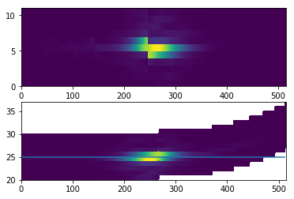

```python
imode=0
itime=-1
tmp = orbp.mharms[imode]

fig, axarr = plt.subplots(2)
axarr[0].pcolormesh(np.flip(np.abs(p3dz[itime,imode]).transpose(), axis=1), shading='flat')
#axarr[0].plot(10 - np.argmin(np.abs(tmp - 25), axis=1))
axarr[1].pcolormesh(smesh, tmp, np.abs(p3dz[itime,imode]), shading='flat')
axarr[1].plot([0,512], [25,25])
```

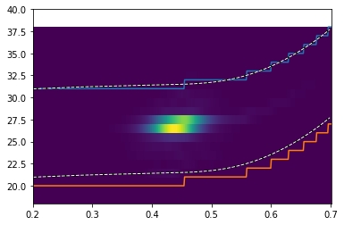

```python
sfmin = 0.2
sfmax = 0.7
deltas = (sfmax - sfmin) / (orbp.ns_ - 3)
deltam = 5

nrange=(min(orbp.n_mode_numbers),max(orbp.n_mode_numbers),orbp.nft)
itrange=widgets.IntSlider(min=0, max=orbp.p3t.shape[0]-1, value=orbp.p3t.shape[0]-1, continuous_update=False)
#@interact(imode=fixed(None), ntor=nrange, itime=itrange, qband=True)
def plot_dense(imode=None, ntor=None, itime=-1, qband=True):
    if imode is None:
        imode, = np.arange(len(orbp.n_mode_numbers))[np.array(orbp.n_mode_numbers)==ntor]
    ntor = orbp.n_mode_numbers[imode]
    tmp = orbp.mharms[imode]
    dense_mmesh = np.meshgrid(np.arange(tmp.shape[0]), np.arange(tmp.max()+1))
    dense_p3dz_t1 = np.zeros(dense_mmesh[0].shape, dtype=np.complex64)
    p3m = orbp.p3m

    mwidth = tmp.shape[1]
    for ispos in np.arange(tmp.shape[0]):
        for imharm, mharm in enumerate(tmp[ispos]):
            dense_p3dz_t1[mharm,ispos] = orbp.p3dz[itime, imode, ispos, imharm]
    plt.pcolormesh(sfmin + deltas * dense_mmesh[0], dense_mmesh[1], np.abs(dense_p3dz_t1))
    plt.plot(sfmin + deltas * dense_mmesh[0][0,:], np.abs(p3m[imode]))
    plt.plot(sfmin + deltas * dense_mmesh[0][0,:], np.abs(p3m[imode])-mwidth)
    if qband:
        sgrid = orbp.orb5s.h5['equil/profiles/generic/sgrid_eq'][:]
        smask = (sgrid >= sfmin) * (sgrid <= sfmax)
        for sign in [-1,1]:
            qstyle = '-' if sign == 0 else '--'
            plt.plot(sgrid[smask], orbp.orb5s.h5['equil/profiles/generic/q'][smask]*ntor + sign*deltam, qstyle, lw=2, color='k')
            plt.plot(sgrid[smask], orbp.orb5s.h5['equil/profiles/generic/q'][smask]*ntor + sign*deltam, qstyle, lw=1, color='w')
    plt.gca().set_ylim(min([np.min(i) for i in orbp.mharms])-2,max([np.max(i) for i in orbp.mharms])+2)
    return plt.gcf(), plt.gca()

fig, ax = plot_dense(ntor=26, itime=-1, qband=True)
```

### Data usage:

#### 2D (nfreq_phipol):

```
* potsc = nchi * ns (allows us to get phi(m,s,t))
* potsp = nphi * ns (allows us to get phi(n,s,t) + frequency measurements for each toroidal mode)
* total = (nphi + nchi) * ns
```

#### new 3D (nfreq_3d && nsel_3d_diag = rhs_f):

```
pot3d = 2 * (nfilt2-nfilt1+1) * (2 * delta_m + 1) * (ns + nidbas)
```

#### old 3D (nfreq_3d && nsel_3d_diag = real):

```
phi = nphi * nchi * ns (1+moments)
```

- both 3Ds are equivalent
- both can be used to reconstruct 2D
- both allow us to get phi(n,m,s,t)

#### Reductions:

`3D new / 3D old = (2 * nmodes * (2*delta_m + 1)) / nphi * nchi`  
`3D new / 2D = (2 * nmodes * (2*delta_m + 1)) / (nphi + nchi)`

#### Example 1:

```
ns    = 512
nchi  = 256
nphi  = 128
deltam =  5
nfilt1 = 25
nfilt2 = 26
cubic splines
```

2D:  
512*(256+128) = 196 608 data points per diagnostic step

new 3D:  
2 * (2 modes) * (2 * 5 + 1) * (512+3) = 22 660 data points per diagnostic step

old 3D:  
512 * 256 * 128 = 16 777 216 data points per diagnostic step (assuming no moments stored).

new / old 3D = 740x reduction  
new 3D / 2D = 8.7x reduction

#### Example 2:

```
Same case, full radius:
q_max from ~1.25 to ~3.5
ns   ~ doubles
nchi ~ doubles
nphi   constant
```

```
2D     -> quadruples to   786432
new 3D -> doubles    to    45320
old 3D -> quadruples to 67108864
new / old 3D = ~1500
```

#### Largest example:

```
ns   ~ 1000
nchi ~ 1500
nphi ~  250
old 3D ~ 375M. Including moments data each 3D file ~10-60GB
```

### Open issues:

- 1D moments diagnostic previous done in nfreq_3d
- Absolute normalizations*
- spline coefficients -> radial coordinate*

*Noe's MATLAB script probably already corrects for these

### Outlook

Alberto plans to add density(isp) & current(isp) options to new diagnostics.  
(If needed): 3D new -> 3D old automatic conversion.

#### 3D field data visualisation:

Does anyone currently use Visit/paraview/etc with the full 3D data? Are people interested in building 3D rendering workflows?

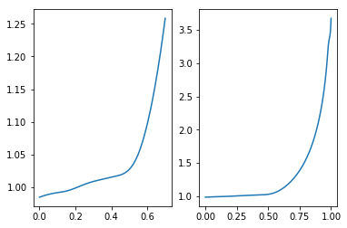

```python
fig, axarr = plt.subplots(1,2)
sgrid = orbp.orb5s.h5['equil/profiles/generic/sgrid_eq'][:]
smask = sgrid <= 0.7
axarr[0].plot(sgrid[smask], orbp.orb5s.h5['equil/profiles/generic/q'][smask])
smask = sgrid <= 1.0
axarr[1].plot(sgrid[smask], orbp.orb5s.h5['equil/profiles/generic/q'][smask])
```